# CRP Tables

César Higgins

2023-01-19

# Import Data

After Stata Analysis, imported file to create tables for descriptive statistics

```r
# import data from STATA crp_data_analysis.dta for data analysis and creation of descriptive tables
rm(list = ls())
source_dir_dta <- "/Users/cesarhiggins/Documents/CRP Dementia/STATA/"
dementia_inc_final <- read_dta(paste0(source_dir_dta, "crp_data_incidence_analysis.dta"))
```

# Table 1 by Cognitive Status

Distribution of baseline sample characteristics by dementia status after 6-year of follow-up, United States Health and Retirement Study, 2006 and 2008

```r
# Table 1


table1_data <- dementia_inc_final %>%
  dplyr::select("dementia", "race", "sex", "edu_cat", "education", "age", "alcohol", "smoke", "bmi", "chronic", "baseline_crp", "APOE2010_bin", "t_dementia", "wave")

table1_data <- table1_data %>%
                mutate(dementia_f = case_when(
                  dementia==0 ~ "Normal",
                  dementia==1 ~ "Dementia"
                )) %>%
                mutate(apoe4 = case_when(
                APOE2010_bin==0 ~ "No copy",
                APOE2010_bin==1 ~ "At least 1 copy"
                )) %>%
                mutate_at(vars(apoe4), as.factor) %>%
                mutate(race_f = case_when(
                  race==0 ~ "White-NH",
                  race==1 ~ "Black-NH",
                  race==2 ~ "Hispanic"
                )) %>%
                mutate(chronic_f = case_when(
                  chronic==0 ~ "No",
                  chronic>=1 ~ "At least 1"
                )) %>%
                mutate(edu_cat_f = case_when(
                  edu_cat==1 ~ "> College",
                  edu_cat==2 ~ "College/Some",
                  edu_cat==3 ~ "HS or <"
                )) %>%
                mutate(sex_f = case_when(
                  sex==1 ~ "Female",
                  sex==2 ~ "Male"
                )) %>%
                mutate(smoke_f = case_when(
                  smoke==0 ~ "Never",
                  smoke==1 ~ "Current/Former"
                )) %>%
                mutate(time = t_dementia) %>%
                mutate_at(vars(time), as.numeric) %>%
                mutate_at(vars(chronic), as.numeric)

table1_data <- table1_data %>%
  dplyr::select("dementia_f", "baseline_crp", "age", "race_f", "sex_f", "edu_cat_f", "alcohol", "smoke_f", "bmi", "chronic_f", "apoe4", "time", "wave", "chronic")

table1_data_nm <- table1_data %>% na.omit()


table1_cognition <- table1_data_nm %>%
  tbl_summary(
    by = dementia_f, missing = "no",
    statistic = list(all_continuous() ~ "{mean} ({sd})",
                     all_categorical() ~ "{n}  ({p}%)"),
    digits = all_continuous() ~ 2,
     label = list(
                baseline_crp ~ "hsCRP",
                age ~ "Age",
                race_f ~ "Race",
                sex_f ~ "Gender",
                edu_cat_f ~ "Educational Category",
                alcohol ~ "Alcohol Use",
                smoke_f ~ "Smoking",
                bmi ~ "Body Mass Index",
                chronic_f ~ "Chronic Conditions",
                apoe4 ~ "APOE-e4",
                time ~ "Time",
                wave ~ "Wave")) %>%
  add_overall() %>%
  add_p(list(all_continuous() ~ "aov"),
        pvalue_fun = ~style_pvalue(.x, digits = 3)) %>%
  bold_p() %>%
  bold_labels()

table1_cognition
```

| **Characteristic** | **Overall**, N = 5,143<sup>1</sup> | **Dementia**, N = 795<sup>1</sup> | **Normal**, N = 4,348<sup>1</sup> | **p-value**<sup>2</sup> |
| --- | --- | --- | --- | --- |
| hsCRP | 4.18 (7.70) | 5.13 (11.28) | 4.00 (6.83) | <0.001 |
| Age | 66.36 (9.90) | 75.64 (9.62) | 64.66 (8.97) | <0.001 |
| Race |  |  |  | <0.001 |
| Black-NH | 488 (9.5%) | 171 (22%) | 317 (7.3%) |  |
| Hispanic | 376 (7.3%) | 103 (13%) | 273 (6.3%) |  |
| White-NH | 4,279 (83%) | 521 (66%) | 3,758 (86%) |  |
| Gender |  |  |  | 0.235 |
| Female | 3,189 (62%) | 478 (60%) | 2,711 (62%) |  |
| Male | 1,954 (38%) | 317 (40%) | 1,637 (38%) |  |
| Educational Category |  |  |  | <0.001 |
| > College | 602 (12%) | 25 (3.1%) | 577 (13%) |  |
| College/Some | 1,109 (22%) | 68 (8.6%) | 1,041 (24%) |  |
| HS or < | 3,432 (67%) | 702 (88%) | 2,730 (63%) |  |
| Alcohol Use | 0.74 (1.27) | 0.40 (1.07) | 0.80 (1.29) | <0.001 |
| Smoking |  |  |  | 0.168 |
| Current/Former | 2,835 (55%) | 456 (57%) | 2,379 (55%) |  |
| Never | 2,308 (45%) | 339 (43%) | 1,969 (45%) |  |
| Body Mass Index | 28.46 (5.75) | 27.17 (5.38) | 28.69 (5.78) | <0.001 |
| Chronic Conditions |  |  |  | <0.001 |
| At least 1 | 4,223 (82%) | 719 (90%) | 3,504 (81%) |  |
| No | 920 (18%) | 76 (9.6%) | 844 (19%) |  |
| APOE-e4 |  |  |  | <0.001 |
| At least 1 copy | 1,363 (27%) | 258 (32%) | 1,105 (25%) |  |
| No copy | 3,780 (73%) | 537 (68%) | 3,243 (75%) |  |
| Time |  |  |  | <0.001 |
| 2 | 302 (5.9%) | 302 (38%) | 0 (0%) |  |
| 4 | 269 (5.2%) | 269 (34%) | 0 (0%) |  |
| 6 | 4,572 (89%) | 224 (28%) | 4,348 (100%) |  |
| Wave |  |  |  | <0.001 |
| 2006 | 2,597 (50%) | 339 (43%) | 2,258 (52%) |  |
| 2008 | 2,546 (50%) | 456 (57%) | 2,090 (48%) |  |
| chronic |  |  |  |  |
| 0 | 920 (18%) | 76 (9.6%) | 844 (19%) |  |
| 1 | 1,430 (28%) | 137 (17%) | 1,293 (30%) |  |
| 2 | 1,420 (28%) | 216 (27%) | 1,204 (28%) |  |
| 3 | 820 (16%) | 182 (23%) | 638 (15%) |  |
| 4 | 371 (7.2%) | 107 (13%) | 264 (6.1%) |  |
| 5 | 131 (2.5%) | 46 (5.8%) | 85 (2.0%) |  |
| 6 | 45 (0.9%) | 29 (3.6%) | 16 (0.4%) |  |
| 7 | 6 (0.1%) | 2 (0.3%) | 4 (<0.1%) |  |

<sup>*1*</sup> Mean (SD); n (%) <sup>*2*</sup> One-way ANOVA; Pearson's Chi-squared test

```r
# Save analytic sample size data
# save(table1_data_nm, file=paste0(source_dir_dta, "Complete_hsCRP.RData"))
```

# Supplemental Table 4

Supplemental Table 4: Distribution of baseline sample characteristics by percentiles of C-reactive protein, United States Health and Retirement Study, 2006 and 2008

```r
table1_data_nm %>%
  summarize("Obs" = n(),
  "Mean" =mean(baseline_crp,na.rm=TRUE),
  "SD" = sd(baseline_crp,na.rm=TRUE),
  "Min" = min(baseline_crp, na.rm=TRUE),
  "Max" = max(baseline_crp, na.rm=TRUE),
  "25%" = quantile(baseline_crp, probs=0.25, na.rm=TRUE), "50%" = quantile(baseline_crp, probs=0.50, na.rm=TRUE), "75%" = quantile(baseline_crp, probs=0.75, na.rm=TRUE),
  "IQR" = IQR(baseline_crp, na.rm=TRUE)) %>%
  na.omit()
```

```
#> # A tibble: 1 × 9
#>     Obs  Mean    SD   Min   Max `25%` `50%` `75%`   IQR
#>   <int> <dbl> <dbl> <dbl> <dbl> <dbl> <dbl> <dbl> <dbl>
#> 1  5143  4.18  7.70  0.02  173.  0.96  1.97  4.57  3.61
```

```r
table2_data <- dementia_inc_final %>%
  mutate(crp_cat = case_when(
    baseline_crp < 0.96 ~ 0,
    baseline_crp >= 0.96 & baseline_crp < 1.97 ~ 1,
    baseline_crp >= 1.97 & baseline_crp < 4.57 ~ 2,
    baseline_crp >= 4.57 ~ 3
  )) %>%
  mutate(dementia_f = case_when(
                  dementia==0 ~ "Normal",
                  dementia==1 ~ "Dementia"
                )) %>%
                mutate(apoe4 = case_when(
                APOE2010_bin==0 ~ "No copy",
                APOE2010_bin==1 ~ "At least 1 copy"
                )) %>%
                mutate_at(vars(apoe4), as.factor) %>%
                mutate(race_f = case_when(
                  race==0 ~ "White-NH",
                  race==1 ~ "Black-NH",
                  race==2 ~ "Hispanic"
                )) %>%
                mutate(chronic_f = case_when(
                  chronic==0 ~ "No",
                  chronic>=1 ~ "At least 1"
                )) %>%
                mutate(edu_cat_f = case_when(
                  edu_cat==1 ~ "> College",
                  edu_cat==2 ~ "College/Some",
                  edu_cat==3 ~ "HS or <"
                )) %>%
                mutate(sex_f = case_when(
                  sex==1 ~ "Female",
                  sex==2 ~ "Male"
                )) %>%
                mutate(smoke_f = case_when(
                  smoke==0 ~ "Never",
                  smoke==1 ~ "Current/Former"
                )) %>%
                mutate(time = t_dementia) %>%
                mutate_at(vars(time), as.numeric) %>%
                mutate_at(vars(chronic), as.numeric)

table2_data <- table2_data %>%
  dplyr::select("dementia_f", "crp_cat", "age", "race_f", "sex_f", "edu_cat_f", "alcohol", "smoke_f", "bmi", "chronic_f", "apoe4", "time", "wave")

table2_data_nm <- table2_data %>% na.omit()

table2_crp <- table2_data_nm %>%
  tbl_summary(
    by = crp_cat, missing = "no",
    statistic = list(all_continuous() ~ "{mean} ({sd})",
                     all_categorical() ~ "{n}  ({p}%)"),
    digits = all_continuous() ~ 2,
     label = list(
                dementia_f ~ "Dementia",
                age ~ "Age",
                race_f ~ "Race",
                sex_f ~ "Gender",
                edu_cat_f ~ "Educational Category",
                alcohol ~ "Alcohol Use",
                smoke_f ~ "Smoking",
                bmi ~ "Body Mass Index",
                chronic_f ~ "Chronic Conditions",
                apoe4 ~ "APOE-e4",
                time ~ "Time",
                wave ~ "Wave")) %>%
  add_overall() %>%
  add_p(list(all_continuous() ~ "aov"),
        pvalue_fun = ~style_pvalue(.x, digits = 3)) %>%
  bold_p() %>%
  bold_labels()

table2_crp
```

| **Characteristic** | **Overall**, N = 5,143<sup>1</sup> | **0**, N = 1,282<sup>1</sup> | **1**, N = 1,267<sup>1</sup> | **2**, N = 1,306<sup>1</sup> | **3**, N = 1,288<sup>1</sup> | **p-value**<sup>2</sup> |
| --- | --- | --- | --- | --- | --- | --- |
| Dementia |  |  |  |  |  | 0.115 |
| Dementia | 795 (15%) | 195 (15%) | 177 (14%) | 199 (15%) | 224 (17%) |  |
| Normal | 4,348 (85%) | 1,087 (85%) | 1,090 (86%) | 1,107 (85%) | 1,064 (83%) |  |
| Age | 66.36 (9.90) | 66.35 (10.17) | 67.05 (9.77) | 66.60 (9.73) | 65.45 (9.88) | <0.001 |
| Race |  |  |  |  |  | <0.001 |
| Black-NH | 488 (9.5%) | 88 (6.9%) | 75 (5.9%) | 133 (10%) | 192 (15%) |  |
| Hispanic | 376 (7.3%) | 71 (5.5%) | 91 (7.2%) | 107 (8.2%) | 107 (8.3%) |  |
| White-NH | 4,279 (83%) | 1,123 (88%) | 1,101 (87%) | 1,066 (82%) | 989 (77%) |  |
| Gender |  |  |  |  |  | <0.001 |
| Female | 3,189 (62%) | 718 (56%) | 719 (57%) | 836 (64%) | 916 (71%) |  |
| Male | 1,954 (38%) | 564 (44%) | 548 (43%) | 470 (36%) | 372 (29%) |  |
| Educational Category |  |  |  |  |  | <0.001 |
| > College | 602 (12%) | 221 (17%) | 148 (12%) | 124 (9.5%) | 109 (8.5%) |  |
| College/Some | 1,109 (22%) | 297 (23%) | 308 (24%) | 261 (20%) | 243 (19%) |  |
| HS or < | 3,432 (67%) | 764 (60%) | 811 (64%) | 921 (71%) | 936 (73%) |  |
| Alcohol Use | 0.74 (1.27) | 0.83 (1.27) | 0.81 (1.33) | 0.71 (1.26) | 0.60 (1.21) | <0.001 |
| Smoking |  |  |  |  |  | <0.001 |
| Current/Former | 2,835 (55%) | 631 (49%) | 708 (56%) | 743 (57%) | 753 (58%) |  |
| Never | 2,308 (45%) | 651 (51%) | 559 (44%) | 563 (43%) | 535 (42%) |  |
| Body Mass Index | 28.46 (5.75) | 25.89 (4.30) | 27.48 (4.66) | 29.01 (5.34) | 31.40 (6.84) | <0.001 |
| Chronic Conditions |  |  |  |  |  | <0.001 |
| At least 1 | 4,223 (82%) | 972 (76%) | 1,008 (80%) | 1,114 (85%) | 1,129 (88%) |  |
| No | 920 (18%) | 310 (24%) | 259 (20%) | 192 (15%) | 159 (12%) |  |
| APOE-e4 |  |  |  |  |  | <0.001 |
| At least 1 copy | 1,363 (27%) | 447 (35%) | 347 (27%) | 301 (23%) | 268 (21%) |  |
| No copy | 3,780 (73%) | 835 (65%) | 920 (73%) | 1,005 (77%) | 1,020 (79%) |  |
| Time |  |  |  |  |  | 0.009 |
| 2 | 302 (5.9%) | 58 (4.5%) | 80 (6.3%) | 68 (5.2%) | 96 (7.5%) |  |
| 4 | 269 (5.2%) | 71 (5.5%) | 51 (4.0%) | 80 (6.1%) | 67 (5.2%) |  |
| 6 | 4,572 (89%) | 1,153 (90%) | 1,136 (90%) | 1,158 (89%) | 1,125 (87%) |  |
| Wave |  |  |  |  |  | 0.470 |
| 2006 | 2,597 (50%) | 659 (51%) | 640 (51%) | 636 (49%) | 662 (51%) |  |
| 2008 | 2,546 (50%) | 623 (49%) | 627 (49%) | 670 (51%) | 626 (49%) |  |

<sup>*1*</sup> n (%); Mean (SD) <sup>*2*</sup> Pearson's Chi-squared test; One-way ANOVA

# Supplemental Table 2

Supplemental Table 2: Distribution of baseline sample characteristics by racialized social groups in the Health and Retirement Study, 2006 and 2008

```r
table3_data <- dementia_inc_final %>%
                mutate(dementia_f = case_when(
                  dementia==0 ~ "Normal",
                  dementia==1 ~ "Dementia"
                )) %>%
                mutate(apoe4 = case_when(
                APOE2010_bin==0 ~ "No copy",
                APOE2010_bin==1 ~ "At least 1 copy"
                )) %>%
                mutate_at(vars(apoe4), as.factor) %>%
                mutate(race_f = case_when(
                  race==0 ~ "White-NH",
                  race==1 ~ "Black-NH",
                  race==2 ~ "Hispanic"
                )) %>%
                mutate(chronic_f = case_when(
                  chronic==0 ~ "No",
                  chronic>=1 ~ "At least 1"
                )) %>%
                mutate(edu_cat_f = case_when(
                  edu_cat==1 ~ "> College",
                  edu_cat==2 ~ "College/Some",
                  edu_cat==3 ~ "HS or <"
                )) %>%
                mutate(sex_f = case_when(
                  sex==1 ~ "Female",
                  sex==2 ~ "Male"
                )) %>%
                mutate(smoke_f = case_when(
                  smoke==0 ~ "Never",
                  smoke==1 ~ "Current/Former"
                )) %>%
                mutate(time = t_dementia) %>%
                mutate_at(vars(time), as.numeric) %>%
                mutate_at(vars(chronic), as.numeric)

table3_data <- table3_data %>%
  dplyr::select("race_f", "dementia_f", "baseline_crp", "age", "sex_f", "edu_cat_f", "alcohol", "smoke_f", "bmi", "chronic_f", "apoe4", "time", "wave")

table3_data_nm <- table3_data %>% na.omit()


table3_race <- table3_data_nm %>%
  tbl_summary(
    by = race_f, missing = "no",
    statistic = list(all_continuous() ~ "{mean} ({sd})",
                     all_categorical() ~ "{n}  ({p}%)"),
    digits = all_continuous() ~ 2,
     label = list(
                dementia_f ~ "Dementia",
                baseline_crp ~ "hsCRP",
                age ~ "Age",
                sex_f ~ "Gender",
                edu_cat_f ~ "Educational Category",
                alcohol ~ "Alcohol Use",
                smoke_f ~ "Smoking",
                bmi ~ "Body Mass Index",
                chronic_f ~ "Chronic Conditions",
                apoe4 ~ "APOE-e4",
                time ~ "Time",
                wave ~ "Wave")) %>%
  add_overall() %>%
  add_p(list(all_continuous() ~ "aov"),
        pvalue_fun = ~style_pvalue(.x, digits = 3)) %>%
  bold_p() %>%
  bold_labels()

table3_race
```

| **Characteristic** | **Overall**, N = 5,143<sup>1</sup> | **Black-NH**, N = 488<sup>1</sup> | **Hispanic**, N = 376<sup>1</sup> | **White-NH**, N = 4,279<sup>1</sup> | **p-value**<sup>2</sup> |
| --- | --- | --- | --- | --- | --- |
| Dementia |  |  |  |  | <0.001 |
| Dementia | 795 (15%) | 171 (35%) | 103 (27%) | 521 (12%) |  |
| Normal | 4,348 (85%) | 317 (65%) | 273 (73%) | 3,758 (88%) |  |
| hsCRP | 4.18 (7.70) | 6.19 (11.15) | 4.32 (6.29) | 3.94 (7.28) | <0.001 |
| Age | 66.36 (9.90) | 65.53 (9.68) | 63.63 (10.33) | 66.70 (9.85) | <0.001 |
| Gender |  |  |  |  | 0.002 |
| Female | 3,189 (62%) | 338 (69%) | 232 (62%) | 2,619 (61%) |  |
| Male | 1,954 (38%) | 150 (31%) | 144 (38%) | 1,660 (39%) |  |
| Educational Category |  |  |  |  | <0.001 |
| > College | 602 (12%) | 30 (6.1%) | 11 (2.9%) | 561 (13%) |  |
| College/Some | 1,109 (22%) | 75 (15%) | 45 (12%) | 989 (23%) |  |
| HS or < | 3,432 (67%) | 383 (78%) | 320 (85%) | 2,729 (64%) |  |
| Alcohol Use | 0.74 (1.27) | 0.48 (1.14) | 0.65 (1.41) | 0.77 (1.27) | <0.001 |
| Smoking |  |  |  |  | 0.496 |
| Current/Former | 2,835 (55%) | 279 (57%) | 200 (53%) | 2,356 (55%) |  |
| Never | 2,308 (45%) | 209 (43%) | 176 (47%) | 1,923 (45%) |  |
| Body Mass Index | 28.46 (5.75) | 30.69 (6.50) | 29.41 (5.50) | 28.12 (5.61) | <0.001 |
| Chronic Conditions |  |  |  |  | <0.001 |
| At least 1 | 4,223 (82%) | 432 (89%) | 291 (77%) | 3,500 (82%) |  |
| No | 920 (18%) | 56 (11%) | 85 (23%) | 779 (18%) |  |
| APOE-e4 |  |  |  |  | <0.001 |
| At least 1 copy | 1,363 (27%) | 185 (38%) | 83 (22%) | 1,095 (26%) |  |
| No copy | 3,780 (73%) | 303 (62%) | 293 (78%) | 3,184 (74%) |  |
| Time |  |  |  |  | <0.001 |
| 2 | 302 (5.9%) | 80 (16%) | 39 (10%) | 183 (4.3%) |  |
| 4 | 269 (5.2%) | 52 (11%) | 37 (9.8%) | 180 (4.2%) |  |
| 6 | 4,572 (89%) | 356 (73%) | 300 (80%) | 3,916 (92%) |  |
| Wave |  |  |  |  | 0.017 |
| 2006 | 2,597 (50%) | 224 (46%) | 174 (46%) | 2,199 (51%) |  |
| 2008 | 2,546 (50%) | 264 (54%) | 202 (54%) | 2,080 (49%) |  |

<sup>*1*</sup> n (%); Mean (SD) <sup>*2*</sup> Pearson's Chi-squared test; One-way ANOVA

# Supplemental Table 3 & Supplemental Figure 2

Supplemental Table 3 & Supplemental Figure 2: Baseline levels of C-reactive protein (CRP) by racialized social groups and sex in the United States Health and Retirement Study, waves 2006 & 2008

```r
crp_race <- table1_data_nm %>%
  group_by(race_f, sex_f) %>%
  summarize("Obs" = n(),
  "Mean" =mean(baseline_crp,na.rm=TRUE),
  "SD" = sd(baseline_crp,na.rm=TRUE),
  "Min" = min(baseline_crp, na.rm=TRUE),
  "Max" = max(baseline_crp, na.rm=TRUE),
  "25%" = quantile(baseline_crp, probs=0.25, na.rm=TRUE), "50%" = quantile(baseline_crp, probs=0.50, na.rm=TRUE), "75%" = quantile(baseline_crp, probs=0.75, na.rm=TRUE),
  "IQR" = IQR(baseline_crp, na.rm=TRUE)) %>%
  na.omit()

crp_race <- crp_race %>%
            mutate(race_sex = case_when(
              race_f=='Black-NH' & sex_f=='Female' ~ "Black-NH Female",
              race_f=='Black-NH' & sex_f=='Male' ~ "Black-NH Male",
              race_f=='Hispanic' & sex_f=='Female' ~ "Hispanic Female",
              race_f=='Hispanic' & sex_f=='Male' ~ "Hispanic Male",
              race_f=='White-NH' & sex_f=='Female' ~ "White-NH Female",
              race_f=='White-NH' & sex_f=='Male' ~ "White-NH Male"
            )) %>%
            mutate(crp=Mean) %>%
            mutate(LL=Mean-SD) %>%
            mutate(UL=Mean+SD)


crp_race
```

```
#> # A tibble: 6 × 15
#> # Groups:   race_f [3]
#>   race_f   sex_f    Obs  Mean    SD   Min   Max `25%` `50%` `75%`   IQR race_sex
#>   <chr>    <chr>  <int> <dbl> <dbl> <dbl> <dbl> <dbl> <dbl> <dbl> <dbl> <chr>
#> 1 Black-NH Female   338  6.28  9.04  0.04  81.1 1.42   3.6   7.77  6.34 Black-N…
#> 2 Black-NH Male     150  6.00 14.9   0.03 125.  1.14   2.49  5.86  4.72 Black-N…
#> 3 Hispanic Female   232  4.61  5.59  0.08  37.9 1.40   2.5   5.79  4.39 Hispani…
#> 4 Hispanic Male     144  3.85  7.28  0.04  66.7 0.985  1.89  4.04  3.06 Hispani…
#> 5 White-NH Female  2619  4.27  7.57  0.04 173.  1.01   2.13  4.91  3.9  White-N…
#> 6 White-NH Male    1660  3.40  6.77  0.02 121.  0.79   1.55  3.30  2.51 White-N…
#> # … with 3 more variables: crp <dbl>, LL <dbl>, UL <dbl>
```

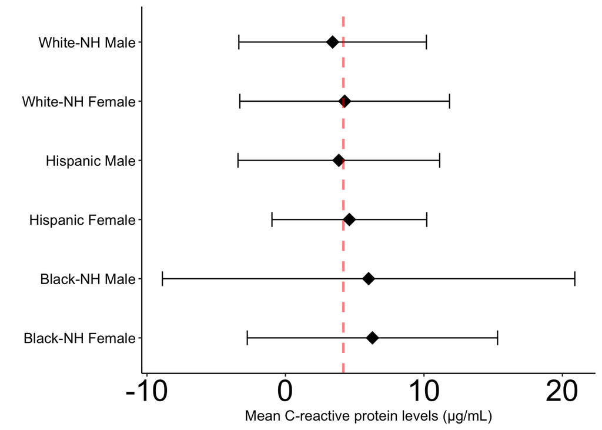

```r
table_base <- ggplot(crp_race, aes(y = race_sex, x = crp)) +
  geom_point(shape = 18, size = 5) +
  geom_errorbarh(aes(xmin = LL, xmax = UL), height = 0.25) +
  geom_vline(xintercept = 4.18, color = "red", linetype = "dashed", cex = 1, alpha = 0.5) +
  xlab("Mean C-reactive protein levels (\u03bcg/mL)") +
  ylab(" ") +
   theme_bw() +
  theme(panel.border = element_blank(),
        panel.background = element_blank(),
        panel.grid.major = element_blank(),
        panel.grid.minor = element_blank(),
        axis.line = element_line(colour = "black"),
        axis.text.y = element_text(size = 12, colour = "black"),
        axis.text.x = element_text(size = 25, colour = "black"),
        axis.title.x = element_text(size = 12, colour = "black"))

table_base
```

```r
tab1 <- table_base +
  labs(title = "space") +
  geom_text(aes(y = race_sex, x = -10, label = sprintf("%0.1f", round(crp, digits = 2))), size = 4) + ## decimal places
  ggtitle("Mean")
```

# Supplemental Table 1

Supplemental Table 1: Distribution of baseline characteristics between included and excluded participants in the United States Retirement Study

```r
# First import analytic sample size and the one that we would like to compare with missing covatiates

rm(list = ls())
source_dir <- "/Users/cesarhiggins/Documents/Dementia project /NIH grant/Data/"
load(paste0(source_dir, "hsCRP_DBS_RAND_baseline_apoe.RData")) # file with all info on baseline covariates

source_dir_dta <- "/Users/cesarhiggins/Documents/CRP Dementia/STATA/"
dementia_inc_final <- read_dta(paste0(source_dir_dta, "crp_data_incidence_analysis.dta")) # file with analytic sample size

baseline_data <- hsCRP_data_dbs_apoe_nm

# Create a dummy variable in the  in the analytic sample, because everyone has values for all covariates missing==0

dementia_inc_final <- dementia_inc_final %>%
                          mutate(missing=0)

myvars_not_missing <- c("HHID", "PN", "missing", "dementia")

dementia_inc_final <- dplyr::select(dementia_inc_final, myvars_not_missing)

data_mising_table <- left_join(baseline_data, dementia_inc_final, by = c("HHID" = "HHID", "PN" = "PN"))

data_mising_table <- data_mising_table %>%
  mutate(missing_f = ifelse(is.na(missing), 1, 0))
```

## Table of Missing Data

```r
data_mising_table <- data_mising_table %>%
  mutate(dementia_f = case_when(
    dementia==0  ~ "normal",
    dementia==1 ~ "dementia"
  )) %>%
  mutate(smoking_f = case_when(
    smoking==0 ~ "never",
    smoking==1 | smoking==2 ~ "current/former"
  )) %>%
  mutate(chronic = case_when(
    wave==2006 ~ R8CONDE,
    wave==2008 ~ R9CONDE
  )) %>%
  mutate(chronic_f = case_when(
    chronic>=1 ~ "At least 1",
    chronic==0 ~ "No Chronic"
  )) %>%
  mutate(apoe = case_when(
    APOE2010_bin==1 ~ "At least 1",
    APOE2010_bin==0 ~ "No copy"
  ))

# NOTE: this table does not need to include dementia status because dementia was assessed prospectively and of course nobody in the excluded sample would have a diagnosis of incident dementia

table1_excluded <- data_mising_table %>%
  dplyr::select("dementia_f", "race_ff", "gender_f", "edu","age", "alcohol", "smoking_f", "bmi", "baseline_crp", "wave" , "missing_f", "apoe", "chronic_f")

table_missing <- table1_excluded %>%
  tbl_summary(
    by = missing_f, missing = "no",
    statistic = list(all_continuous() ~ "{mean} ({sd})",
                     all_categorical() ~ "{n}  ({p}%)"),
    digits = all_continuous() ~ 2,
     label = list(
                  dementia_f ~ "Cognitive Status",
                  baseline_crp ~ "Baseline hsCRP",
                  age ~ "Age",
                  race_ff ~ "Race",
                  gender_f ~ "Gender",
                  edu ~ "Education Category",
                  alcohol ~ "Alcohol",
                  smoking_f ~ "Smoking",
                  bmi ~ "Body Mass Index",
                  chronic_f ~ "Chronic Conditions",
                  apoe ~ "APOE-e4",
                  wave ~ "Wave"
  )) %>%
  add_overall() %>%
  add_p(list(all_continuous() ~ "aov"),
        pvalue_fun = ~style_pvalue(.x, digits = 3)) %>%
  bold_p() %>%
  bold_labels()

table_missing %>% as_flex_table
```

| Characteristic | Overall, N = 8,7811 | 0, N = 5,1431 | 1, N = 3,6381 | p-value2 |
| --- | --- | --- | --- | --- |
| Cognitive Status |  |  |  |  |
| dementia | 795 (15%) | 795 (15%) | 0 (NA%) |  |
| normal | 4,348 (85%) | 4,348 (85%) | 0 (NA%) |  |
| Race |  |  |  | <0.001 |
| Black-NH | 1,057 (12%) | 488 (9.5%) | 569 (16%) |  |
| Hispanic | 794 (9.0%) | 376 (7.3%) | 418 (11%) |  |
| Other-NH | 189 (2.2%) | 0 (0%) | 189 (5.2%) |  |
| White-NH | 6,741 (77%) | 4,279 (83%) | 2,462 (68%) |  |
| Gender |  |  |  | <0.001 |
| Female | 5,290 (60%) | 3,189 (62%) | 2,101 (58%) |  |
| Male | 3,491 (40%) | 1,954 (38%) | 1,537 (42%) |  |
| Education Category |  |  |  | <0.001 |
| > College | 812 (9.2%) | 602 (12%) | 210 (5.8%) |  |
| College/Some | 1,575 (18%) | 1,109 (22%) | 466 (13%) |  |
| HS or < | 6,394 (73%) | 3,432 (67%) | 2,962 (81%) |  |
| Age | 68.12 (10.38) | 66.36 (9.90) | 70.60 (10.52) | <0.001 |
| Alcohol | 0.70 (1.41) | 0.74 (1.27) | 0.64 (1.59) | 0.002 |
| Smoking |  |  |  | 0.005 |
| current/former | 4,950 (56%) | 2,835 (55%) | 2,115 (58%) |  |
| never | 3,831 (44%) | 2,308 (45%) | 1,523 (42%) |  |
| Body Mass Index | 28.33 (5.88) | 28.46 (5.75) | 28.16 (6.05) | 0.018 |
| Baseline hsCRP | 4.55 (8.14) | 4.18 (7.70) | 5.09 (8.69) | <0.001 |
| Wave |  |  |  | <0.001 |
| 2006 | 4,178 (48%) | 2,597 (50%) | 1,581 (43%) |  |
| 2008 | 4,603 (52%) | 2,546 (50%) | 2,057 (57%) |  |
| APOE-e4 |  |  |  | 0.190 |
| At least 1 | 2,373 (27%) | 1,363 (27%) | 1,010 (28%) |  |
| No copy | 6,408 (73%) | 3,780 (73%) | 2,628 (72%) |  |
| Chronic Conditions |  |  |  | <0.001 |
| At least 1 | 7,465 (85%) | 4,223 (82%) | 3,242 (89%) |  |
| No Chronic | 1,316 (15%) | 920 (18%) | 396 (11%) |  |
| 1n (%); Mean (SD) |  |  |  |  |
| 2Pearson's Chi-squared test; One-way ANOVA |  |  |  |  |